心電圖判讀 · 困難病例

# 只有 I 和 aVL 抬起來的那一種

高側壁 ST 抬高型心肌梗塞是最常被放回候診區的 STEMI：抬高的幅度小、只佔兩個導程，而且這兩個導程在心電圖紙上還被拆開放在不同欄。這份教材用兩個真實病例——一個國旗徵象只有一半、一個湊得完整——把它拆到你下次不會再錯過。

高側壁 STEMI aVL Reciprocal change 南非國旗徵象 STEMI equivalents 單機獨立 HTML

Case 1 · 第一關

## 先自己看 60 秒，再往下捲

70 歲男性，例行心電圖。走紙 25 mm/s、10 mm/mV。看完再決定：這張要不要啟動心導管室？

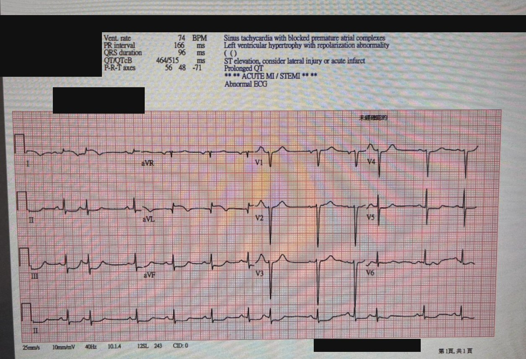

真實臨床影像，已遮除所有可識別個人資訊（姓名、病歷號、生日、檢查日期、病房床號、技術員代號、檢查序號）。保留機器自動測量與自動判讀，是為了教學：**機器已經喊了 STEMI，但這種抬高在人眼下常常被否決掉。** 建議先按「去除格線（灰階）」：粉紅格線退成淡灰後，ST 段相對於基準線的位置會清楚很多。手機請直接點圖片進入放大檢視，可捲動平移。

機器測量

**心室率** 74 bpm **PR** 166 ms  
**QRS** 96 ms **QT/QTcB** 464/515 ms  
**P-QRS-T 軸** 56° / 48° / −71°

機器判讀

為什麼會被漏掉

肢導程電位偏低、機器又同時報了 LVH 與再極化異常——這正是把真正的 ST 抬高解釋成「LVH 造成的」的典型情境。

第二關

診斷心理學

## 高側壁 STEMI 為什麼特別容易漏

原因一

### 它只佔兩個導程，而且被拆開放

標準 4×3 排版裡，**I 在第一欄第一列、aVL 在第二欄第二列**，中間隔著 aVR。眼睛橫著掃過去時，這兩條根本不會同時進入視野。下壁梗塞的 II、III、aVF 是連續三條，前壁是連續一整排 V 導程——只有高側壁被切開。

原因二

### 抬高的絕對幅度通常很小

高側壁的心肌質量比前壁小，肢導程電位又天生低。這裡的抬高常常只有 0.5–1.5 mm，遠不到「一眼就看到」的程度。**把 1 mm 當門檻，而不是把「明顯」當門檻。**

原因三

### LVH 提供了一個太好用的藉口

這張圖同時有 LVH 的電位標準與再極化異常。當機器印出「LVH with repolarization abnormality」，判讀者很容易把所有 ST 變化都掛到 LVH 帳上。但要記得：**LVH strain 在 I、aVL、V5、V6 典型造成的是 ST 壓低，不是抬高。**側壁導程一旦出現抬高，就不容易單純用 LVH 帶過。

原因四

### 沒有主動去看 reciprocal

只盯著抬高的導程，會不停地問自己「這樣算抬高嗎」。改成先看 III：**III 有沒有壓低？**reciprocal 壓低在心包炎、早期再極化幾乎不會出現，它一旦存在，診斷天平立刻大幅倒向缺血。

原因五

### 症狀常常不典型

單獨的 D1／OM 阻塞梗塞範圍小，可能不會有壓迫性胸痛、不會冒冷汗，甚至只是「左肩痠」「悶悶的」。臨床印象輕，判讀的門檻就跟著被拉高。

解法

### 把 I 和 aVL 當成一組來看

養成一個動作：**手指同時指住 I 和 aVL，然後移到 III**。這三條導程一起看，高側壁梗塞就從「隱形」變成「刺眼」。要更保險就**重照一張、和舊片比對**——動態變化是最強的證據。

單一導程

## aVL：十二導程裡最孤獨、也最誠實的一條

它是唯一「向左上看」的肢導程，因此也是唯一能和下壁面對面的導程。很多急性冠心症的第一個線索，只出現在這裡。

解剖位置

### −30°，正對高側壁

aVL 看的是左心室的**前上側壁（anterosuperior / high lateral wall）**，由第一對角枝（D1）與鈍緣枝（OM）供應。I（0°）與它相鄰，同組；V5、V6 看的是比較低位的側壁，屬於另一組。

鏡像關係

### aVL 與 III 相差 150°

在額切面六軸系統裡，這是十二導程中最接近正負對立的一對。因此：**下壁梗塞時 aVL 一定要看**，高側壁梗塞時 III 一定要看。兩條互為對方的驗證。

早期線索

### aVL 的 ST 壓低＝下壁梗塞的最早徵兆

在急性下壁 STEMI，**aVL 的 reciprocal 壓低幾乎百分之百會出現，而且常常比 II、III、aVF 的抬高更早、更明顯**。當一位胸痛病人下壁導程只是「有點怪」，aVL 出現任何程度的 ST 壓低，就要當成下壁梗塞處理、並在數分鐘內重照。

鑑別價值

### 用 aVL 分辨心包炎與梗塞

急性心包炎的 ST 抬高是廣泛且上凹的，**典型上 aVL 不會出現孤立的 reciprocal 壓低**（心包炎唯二可有壓低的是 aVR 與 V1）。所以「下壁抬高 + aVL 壓低」＝梗塞；「廣泛抬高 + PR 段壓低、aVL 無壓低」＝偏心包炎。

本例

### aVL 抬高 + III 壓低

把方向反過來就是這張圖：**aVL 抬 → III 壓**。同一組向量，只是損傷區換到了高側壁。

還有一件事

### aVL 的 T 波形態也在說話

孤立的 aVL T 波倒置在健康人身上可以是正常變異（尤其 QRS 主波向下時）；但**「T 波倒置 + ST 壓低 + 有症狀」**就不能當正常變異，要串聯追蹤。

記憶術

## 南非國旗徵象：D1 阻塞的圖形記憶

當第一對角枝阻塞時，變化的導程在標準 4×3 排版上會連成一個像南非國旗的 Y 字形。Littmann 在 2016 年提出這個記法，用來讓高側壁梗塞「看得見」。

[figure not shown]

組成

**I、aVL、V2 抬高，III 壓低**，而 V1、V3、V4 相對正常——中間跳過 V1、V3 是這個徵象的精髓，也是它和前壁梗塞最大的差別。

為什麼跳過 V3

D1 供應的是左心室**前上側**心肌。V2 的電極位置大致朝向這塊區域，而 V3、V4 對著的是更下方的前壁，所以往往不太受影響。

用法

看到 **V2 抬高但 V3 正常**，別急著說「導程貼錯」——先回頭檢查 I、aVL 和 III。這個組合在文獻上被認為對 D1 阻塞有不錯的指向性，不過原始驗證的樣本數不大，當成線索而非定論比較安全。

**用在這張圖：**本例看得到 I、aVL 的抬高與 III 的 reciprocal 壓低，但 **V2 並沒有跟著抬**——深 S 波之後 ST 大致回到基線。所以嚴格講，國旗徵象在這張圖上**並不完整**，站得住腳的是「側壁抬高 ＋ 下壁 reciprocal 壓低」這一組，而不是完整的 Y 形。  
徵象不齊，並不會因此排除高側壁梗塞——這裡的診斷本來就是靠 I、aVL 與 III 的對應關係撐起來的，V2 只是加分題。至於罪犯血管，V2 沒有參與時有些人會覺得比較偏向鈍緣枝或中間枝而非第一對角枝，但單靠心電圖推罪犯血管一向不太可靠，這點保留給血管攝影。**把國旗徵象當作「提醒你回頭看 I、aVL、III」的觸發器，而不是單獨拿來下診斷的印章。**  
**想看完整版長什麼樣？**往下捲到 Case 2：另一位 47 歲男性的心電圖，I、aVL、**V2** 三個都抬、II、III、aVF 三個都壓，整面旗子是齊的，正好拿來對照這張缺了 V2 的圖。

Case 2 · 對照病例

## 這一次，國旗是完整的

上面那張圖的國旗徵象只有一半——I、aVL 抬、III 壓，但 V2 沒跟上。這裡放第二個病例當對照：**V2 真的抬起來了**，整面旗子湊齊。兩張圖並排看，比任何文字定義都容易記住這個徵象在說什麼。

臨床背景

**47 歲男性。**冠狀動脈三條血管疾病（three-vessel disease, 3VD），臨床表現符合 ST 抬高型心肌梗塞。年齡比第一個病例輕了 23 歲——高側壁梗塞不是老年人的專利。

心電圖

ST **抬高**：I、aVL、**V2**。  
ST **壓低**：II、III、aVF。  
三個抬高配三個下壁導程的 reciprocal 壓低——這就是教科書版本的南非國旗徵象。

處置

心導管確認為 3VD，接受 **PCI 併支架置放**：mid-LAD 一支 DES、proximal LCX 一支 DES。

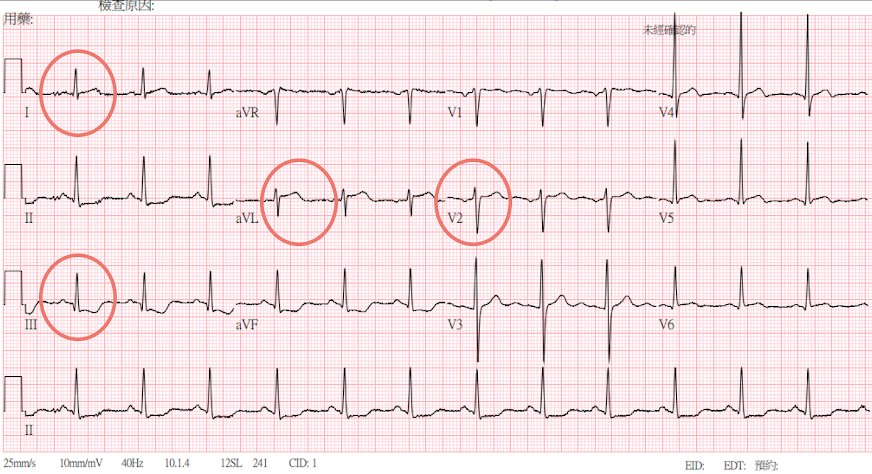

走紙 25 mm/s、10 mm/mV。個案由 **葉洛嘉醫師 M.D.** 與 **蕭喻中醫師 M.D.** 提供並授權教學使用，姓名、病歷號、生日、檢查日期與床號等可識別資訊皆已移除。 圖上的**紅色圓圈是原始個案標註**，圈出的正是 I、aVL、V2 與 III；按「顯示標註」可另外疊上本頁的抬高／壓低框線與導程標示。 建議先按「去除格線（灰階）」再看 V2 的 ST 段。

Case 1（本頁開頭那張）

**國旗不完整。**I、aVL 抬高，III、aVF reciprocal 壓低——但 V2 的 ST 在深 S 波之後大致回到基線。診斷靠的是「側壁抬高＋下壁壓低」這一組對應關係，V2 只是加分題。機器已經喊了 STEMI，但同時報 LVH 與再極化異常，很容易讓人把抬高解釋掉。

Case 2（這一張）

**國旗完整。**I、aVL、V2 三個抬高，II、III、aVF 三個壓低，Y 字形在 4×3 版面上一次到位。這張圖的價值在於：它讓你知道「完整版長什麼樣」，回頭再看 Case 1 時，才分得出哪些是徵象本體、哪些是可有可無的配件。

**兩張圖一起讀的重點：**國旗徵象**不齊，不能拿來排除**高側壁梗塞。Case 1 少了 V2 依然是高側壁 STEMI；Case 2 湊齊了也只是讓辨識變容易。真正撐起診斷的，始終是 **I、aVL 的抬高與下壁導程 reciprocal 壓低之間的對應關係**。把國旗當成「提醒你回頭看 I、aVL、III」的觸發器就好。

### 血管攝影對照

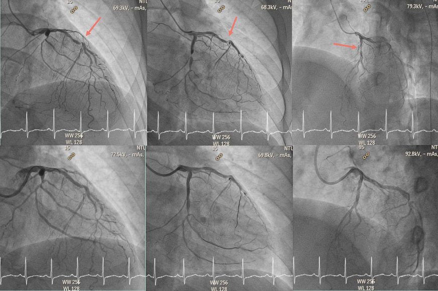

六格為同一位病人的冠狀動脈攝影：**上排三個投照角度的紅色箭頭，是原始個案標註的病灶位置**；下排為對應的術後影像。 影像已去識別化。本頁不從這幾張截圖自行判讀投照角度或血管節段——血管的認定依臨床紀錄，即 mid-LAD 與 proximal LCX 各置放一支 DES。

**把話說到剛好，不要多說：**南非國旗徵象在文獻上被連結到**第一對角枝（D1）阻塞**，而這位病人的紀錄寫的是 mid-LAD 與 proximal LCX 置放支架。兩者並不矛盾——發出 D1 的那段 mid-LAD 若阻塞，供應的正是同一塊前上側心肌，心電圖可以長得一模一樣。 但必須誠實標記三件事：**（一）**來源資料沒有指明這次急性事件的**罪犯血管（culprit vessel）**究竟是哪一處；**（二）**這是 3VD，多處病灶並存時，心電圖本來就無法乾淨地指向單一血管；**（三）**本頁取得的是臨床來信與標註後的影像，沒有發作時間、troponin、術前後 TIMI blood flow 或左心室功能等資料。 所以正確的說法是**「這張心電圖的型態指向高側壁（D1／mid-LAD 發出對角枝的那一段）所供應的區域（territory）」**，而不是「國旗徵象證實了罪犯血管是 D1」。心電圖推罪犯血管一向只能當假設，答案在導管室。

**個案提供 Case contributed by**  
葉洛嘉醫師 M.D. · 蕭喻中醫師 M.D.  
感謝兩位醫師提供本案例的心電圖與血管攝影影像並授權教學使用。病人之可識別資訊皆已移除。

導管室之前

## 抬在 I 和 aVL，兇手是誰

最常見

### 第一對角枝 D1

孤立的高側壁抬高（I、aVL ± V2）最典型的犯罪血管。梗塞面積小、血液動力學常常穩定，也因此容易被低估。

次常見

### 鈍緣枝 OM（LCx 系統）

抬高常同時延伸到 V5、V6；若同時有 V1–V3 的 ST 壓低與高 R 波，要想到**合併後壁**，加做 V7–V9。

別忘了

### 中間枝 ramus intermedius

三分叉解剖的病人才有。表現介於 D1 與 OM 之間，同樣以 I、aVL 為主。

警訊組合

### I、aVL 抬高 + 廣泛前壁抬高

代表阻塞位在**近端 LAD（D1 分支之前）**，梗塞面積大、風險高，屬於必須最快處理的一群。

反過來想

### 下壁抬高 + aVL 壓低

典型的下壁 STEMI。此時要進一步比較 III 與 II 的抬高幅度：**III > II** 偏向右冠狀動脈，並記得加做 V4R 找右心室梗塞。

共通動作

### 先啟動，再細分

辨認出「這是 STEMI」就足以啟動流程；犯罪血管的推測是幫助導管室預期，不是延後決策的理由。

圖鑑一

## 其他同樣困難的 ST 抬高與等價型態

高側壁只是其中一種。以下這些型態的共同點是：**要嘛抬高幅度不夠、要嘛根本不以抬高呈現**，但背後都是需要立刻打通的血管。下方波形為示意圖，用來記住形狀，不代表真實比例。

Hyperacute T waves

### 超急性 T 波

T 波變得**又寬又胖、底部變寬、對稱**，相對於 QRS 顯得過大。它出現在 ST 抬高**之前**，可能只維持幾分鐘到幾十分鐘。

**動作：**症狀相符就**每 10–15 分鐘重照一張**，並比對舊片。這是最常被「等抽血結果」拖掉的黃金時間。

de Winter pattern

### de Winter 型態

V1–V6 的 J 點**下移**、ST 段呈**上斜壓低**，緊接著高聳對稱的 T 波，aVR 常有輕微抬高。全程**沒有**典型的 ST 抬高。

**意義：**約 2% 的 LAD 近端完全阻塞以此表現，屬 **STEMI equivalent**，直接送導管室。

Modified Sgarbossa

### 左束支傳導阻滯／節律器

原始 Sgarbossa：**一致性抬高 ≥1 mm**（5 分）、V1–V3 一致性壓低 ≥1 mm（3 分）、不一致性抬高 ≥5 mm（2 分）。**修正版（Smith）**把最後一項改成**比例**：ST 抬高 ÷ 前面 S 波深度 **≥ 0.25**。

**重點：**「LBBB 就不能判讀」是過時的說法。用比例去看，一樣能診斷。

Posterior MI

### 正後壁梗塞（鏡像）

V1–V3 出現**水平 ST 壓低 + 高 R 波（R/S > 1）+ 直立 T 波**——這是後壁抬高的鏡像。把圖上下顛倒看，就是一個標準的 STEMI。

**動作：**加做 **V7–V9**，抬高 ≥0.5 mm 即可診斷。常與下壁或側壁梗塞並存。

aVR elevation

### aVR 抬高 + 廣泛 ST 壓低

**≥6 個導程 ST 壓低**，同時 aVR（± V1）ST 抬高。代表左主幹、近端 LAD 或嚴重三條血管病變造成的**廣泛心內膜下缺血**。

**注意：**這不是單一血管的透壁梗塞，處置策略不同（多半需要更完整的評估與外科諮詢），但持續缺血合併不穩定時，同樣屬於立即侵入性處置的適應症。

Shark fin / giant R wave

### 鯊魚鰭（巨 R 波型）

QRS、ST 與 T 完全融合成一個寬大的三角形，看起來像是心室頻脈或寬 QRS 節律。**不要被「寬 QRS」誤導。**

**意義：**大面積透壁缺血（常見左主幹或近端 LAD），死亡率極高，是最緊急的一群。

Terminal QRS distortion

### 終末 QRS 扭曲

在 V2 或 V3，**既沒有 S 波、也沒有 J 波切跡**，ST 直接從 R 波下降支接上去。

**價值：**這個特徵**不會出現在早期再極化**，因此是「微幅抬高到底是缺血還是良性變異」時，非常有力的一票。

Wellens syndrome

### Wellens 型態

V2–V3 出現**雙相（A 型）或深而對稱的倒置 T 波（B 型）**，通常在**胸痛緩解之後**才浮現，心肌酵素可能正常。

**陷阱：**它不是 ST 抬高，卻代表 LAD 近端的臨界狹窄。**不要做運動心電圖**，安排血管攝影。

RV infarction · V4R

### 右心室梗塞

下壁 STEMI 且 **III 抬高幅度 > II**、V1 也有抬高時，要懷疑右冠狀動脈近端阻塞合併右心室梗塞。診斷靠**右側導程 V4R 抬高 ≥0.5 mm**。

**治療差異：**前負荷依賴。**硝酸鹽與嗎啡可能造成嚴重低血壓**，先給輸液。

圖鑑二

## 長得像 STEMI，但不是

認得出假象，才敢在真的很微弱時果斷啟動。這五種是臨床上最常造成誤判的來源。

Early repolarization

### 早期再極化

J 點有**切跡或頓挫（fish-hook）**、ST 段**上凹**、T 波高聳且與 ST 比例協調，最常見於 V2–V5 的年輕男性。

**分辨：**沒有 reciprocal 壓低、沒有終末 QRS 扭曲、跨時間**不變化**。仍難分辨時可用 Smith 四變數公式（QTc、V2 的 QRS 振幅、V4 的 R 波振幅、V3 於 J 點後 60 ms 的抬高），數值愈高愈偏向 LAD 阻塞。

Acute pericarditis

### 急性心包炎

**廣泛、上凹的 ST 抬高**，跨越多個血管分佈區；**PR 段壓低**（aVR 則是 PR 抬高）；可見 Spodick 徵象（TP 段下斜）。

**分辨：**沒有 reciprocal 壓低（aVR、V1 除外）、沒有 Q 波、抬高幅度不隨導程分佈成區塊。**V6 的 ST/T 比值 > 0.25** 偏向心包炎。

LVH with strain

### 左心室肥厚（strain）

高電位；在 **I、aVL、V5、V6 是不一致性的 ST 壓低與不對稱倒置 T**；在 V1–V3 因為深 S 波而出現**上凹的抬高**。

**關鍵：**LVH 在側壁典型造成的是**壓低**。所以本例 I、aVL 的抬高不太能推給 LVH——這是這張圖比較說得過去的切入點。

LV aneurysm

### 左心室動脈瘤（陳舊梗塞）

前壁導程有**成形良好的 QS 波**，伴隨**持續多年不變**的 ST 抬高，T 波相對小。

**分辨：**拿舊心電圖比對是唯一可靠方法。輔助法則：V1–V4 的 **T 波振幅總和 ÷ QRS 振幅總和 < 0.22** 偏向動脈瘤而非急性梗塞。

Brugada type 1

### Brugada 第一型

V1–V2 出現**穹窿狀（coved）抬高 ≥2 mm**，接著是倒置的 T 波，形態像一個下滑的屋簷。

**分辨：**沒有 reciprocal 變化，形態在發燒、鈉離子通道阻斷劑下會變化。**意義是猝死風險，不是血管阻塞。**

Hyperkalemia

### 高血鉀

P 波變小或消失、QRS 變寬、T 波**又高又尖又窄（基底狹窄）**；嚴重時 V1–V2 可出現類似 STEMI 的抬高（dialyzable current of injury）。

**動作：**心電圖看起來「不像任何一種梗塞」又很怪的時候，**先驗血鉀**。治療是鈣、胰島素與透析，不是導管室。

**還有幾個要記得：**壓力性心肌病（Takotsubo）、急性心肌炎、蜘蛛膜下腔出血、低溫（Osborn 波）、心室節律器起搏、以及左束支傳導阻滯本身，都可以造成 ST 抬高。**它們共通的鑑別工具只有三個：reciprocal 變化、與症狀的時序關係、以及跟舊心電圖的比較。**

帶著走

## 看到疑似高側壁抬高的六個動作

1. **把 I 和 aVL 併在一起看**手指同時壓住這兩條，忽略中間的 aVR。判斷 J 點相對於 PR 段基準線的位置，不是相對於等電位線的感覺。
2. **立刻檢查 III 和 aVF**有沒有 reciprocal 壓低？有，診斷幾乎確立；沒有，也不能排除（小面積梗塞可能沒有），但要提高後續追蹤的密度。
3. **看 V2 有沒有跟著抬、V3 是不是正常**符合南非國旗徵象的排列，指向第一對角枝。
4. **用比例，不要只用毫米**低電位導程的 1 mm、深 S 波後面的 3 mm，意義完全不同。看 ST 抬高與前面 S 波（或整體 QRS）的比例。
5. **調出舊心電圖比對**「這是新的變化嗎」永遠比「這抬高幾 mm」更有診斷力。同時安排 **15–30 分鐘後重照**，並在症狀變化時立即重照。
6. **症狀相符就啟動，不要等 troponin**STEMI 是心電圖加臨床的診斷。第一套心肌酵素正常，完全不能排除正在進行中的血管阻塞。

**額外導程的三個時機：**懷疑後壁 → **V7–V9**；下壁 STEMI → **V4R**（右心室）；懷疑高側壁但肢導程模稜兩可 → 把 **V5、V6 往上移一到兩個肋間**，有時能把抬高放大出來。

第三關

## 八題自測

選一個答案，會立刻顯示解說。

Q1本教材這張心電圖，最符合的診斷是？

**答案：高側壁 STEMI。**I 與 aVL 抬高（同屬高側壁組、彼此相鄰），加上 III 與 aVF 的 reciprocal 壓低。LVH 只能解釋側壁的壓低，解釋不了抬高。

Q2在額切面上，aVL 的「鏡像」導程是哪一條？

**答案：III。**aVL 在 −30°、III 在 +120°，相差 150°，是十二導程中最接近正負對立的一對。因此 aVL 抬 → III 壓、下壁抬 → aVL 壓。

Q3急性下壁 STEMI 最早、最敏感的心電圖變化，常出現在哪裡？

**答案：aVL 的 ST 壓低。**在急性下壁梗塞幾乎必然出現，且常早於下壁導程的抬高。胸痛病人下壁導程模稜兩可時，aVL 的任何壓低都要當一回事。

Q4「南非國旗徵象」的組成是？

**答案：I、aVL、V2 抬高 + III 壓低。**V1、V3 相對正常是這個型態的精髓，較支持**第一對角枝**阻塞。  
提醒：這是徵象的**定義**。本教材這張心電圖的 V2 並沒有抬高，所以國旗徵象在這裡並不完整——診斷靠的是 I、aVL 的抬高與 III 的 reciprocal 壓低。

Q5胸痛病人有左束支傳導阻滯，V3 的 S 波深 30 mm、同一導程 ST 抬高 8 mm。怎麼判讀？

**答案：ST/S ＝ 8/30 ＝ 0.27 ≥ 0.25。**修正版（Smith）Sgarbossa 以比例取代固定的 5 mm 門檻，敏感度大幅提升。「LBBB 不能判讀」已是過時說法。

Q6V1–V3 出現水平 ST 壓低、高 R 波（R/S > 1）與直立 T 波。下一步最該做什麼？

**答案：加做 V7–V9。**這是正後壁梗塞在前胸導程的鏡像。V7–V9 抬高 ≥0.5 mm 即可診斷，屬於再灌流的適應症。

Q7下列哪一項，最能把急性缺血和早期再極化／心包炎區分開來？

**答案：reciprocal ST 壓低。**它在早期再極化幾乎不出現，在心包炎也只限於 aVR 與 V1。一旦出現在解剖上對側的導程，強烈支持缺血。

Q8左心室肥厚合併 strain，在 I、aVL、V5、V6 典型造成的 ST 變化是？

**答案：不一致性的 ST 壓低。**LVH 在**側壁**造成壓低、在 V1–V3 因深 S 波造成上凹的抬高。因此側壁導程若出現抬高，不能推給 LVH——這正是本例的判讀關鍵。

依據

## 參考資料

- Fourth Universal Definition of Myocardial Infarction（2018）：J 點 ST 抬高的診斷門檻——除 V2–V3 外的所有導程 ≥1 mm；V2–V3 為男性 ≥40 歲 ≥2 mm、男性 <40 歲 ≥2.5 mm、女性 ≥1.5 mm。
- 2023 ESC Guidelines for the management of acute coronary syndromes：STEMI equivalents、後壁與右側額外導程的建議。
- Littmann L. *South African flag sign: a teaching tool for easier ECG recognition of high lateral infarct.* Am J Emerg Med, 2016.
- Birnbaum Y, Drew BJ 等人關於下壁梗塞中 aVL reciprocal ST 壓低的系列研究。
- Sgarbossa EB, et al. *Electrocardiographic diagnosis of evolving acute myocardial infarction in the presence of left bundle-branch block.* N Engl J Med, 1996.
- Smith SW, et al. *Diagnosis of ST-elevation myocardial infarction in the presence of left bundle branch block with the ST-elevation to S-wave ratio in a modified Sgarbossa rule.* Ann Emerg Med, 2012.
- de Winter RJ, et al. *A new ECG sign of proximal LAD occlusion.* N Engl J Med, 2008.
- Smith SW 等人關於「微幅前壁抬高 vs 早期再極化」的四變數公式，以及左心室動脈瘤 T/QRS 比值法則。
- Life in the Fast Lane（LITFL）ECG Library：各型態的圖例整理。

**使用聲明：**本教材為臨床教育用途，心電圖影像已完成去識別化處理，不包含任何可辨識個人之資訊。內容不取代臨床判斷、機構流程與最新指引；實際處置請依所屬醫療機構規範與主治醫師的臨床判斷。

[figure not shown]